# Analysis Approach for Assessing Textile Preferences on Net Use: Malawi

## Évaluer la distribution des textiles à travers les covariables

Les moustiquaires de différents textiles sont-ils uniformément répartis sur les groupes socioeconomiques?

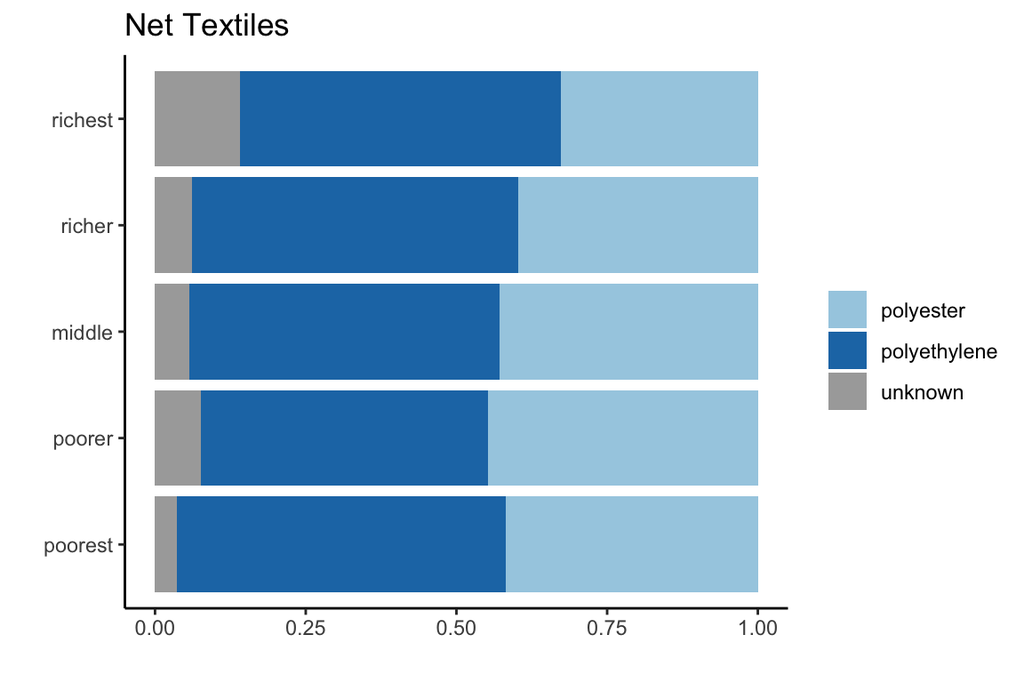

Les moustiquaires de différents textiles sont-ils uniformément répartis dans les milieux urbains/ruraux?

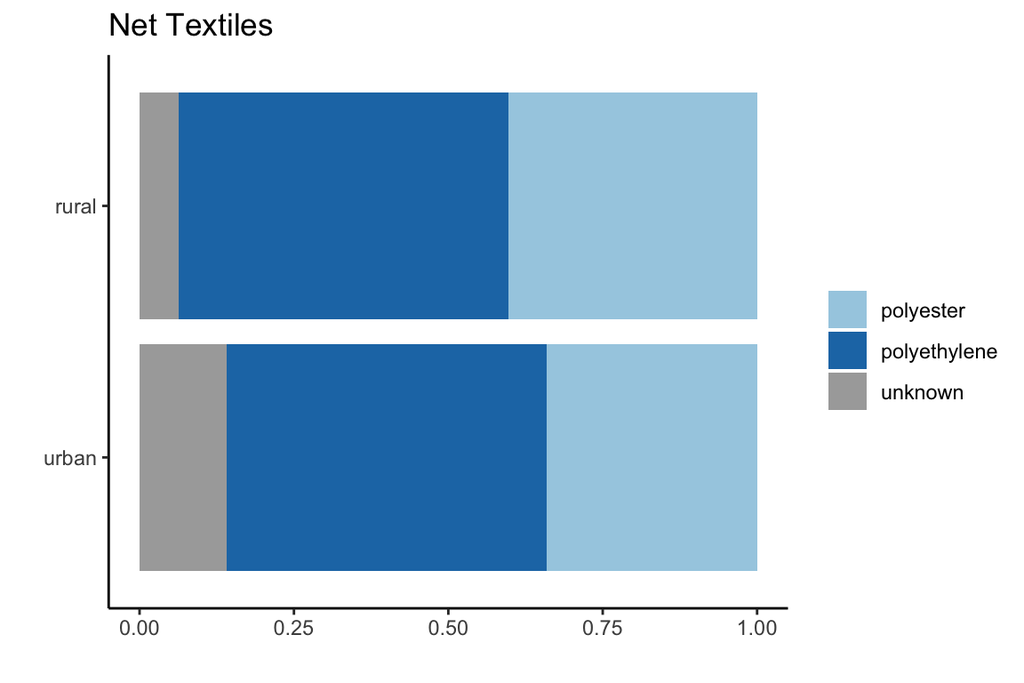

Les moustiquaires d’un certain textile sont-ils uniformément plus anciens que l’autre textile ? Par exemple, si la plupart des moustiquaires de la dernière campagne étaient en polyester et que les moustiquaires de la campagne précédente étaient en polyéthylène, nous nous attendrions à voir des différences dans l’utilisation des moustiquaires en raison de l’âge de la moustiquaire (les moustiquaires plus anciennes sont usées et moins utilisées), qui se confondrait avec le textile.

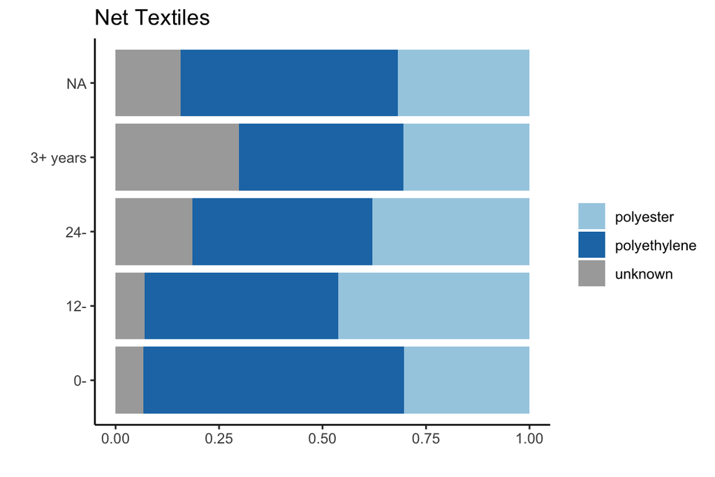

Les moustiquaires de différents textiles sont-ils uniformément représentés au cours des mois où l’enquête a été menée ?

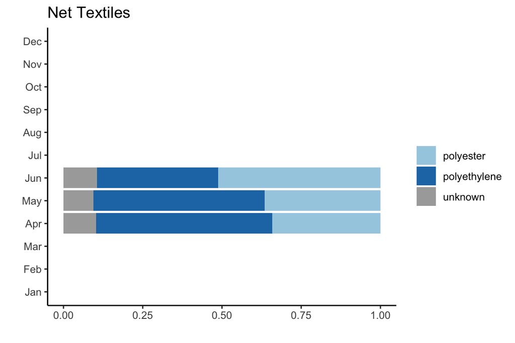

Les moustiquaires de différents textiles sont-elles uniformément représentées dans l’offre nette des ménages ?

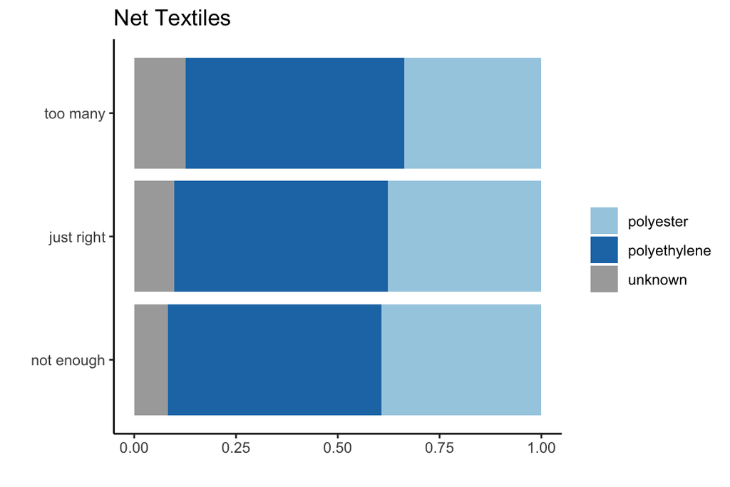

## Évaluer la disponibilité des textiles au sein des ménages

Quelle proportion de ménages possèdent des moustiquaires des deux textiles ? Les ménages qui possèdent les deux types sont-ils différents des ménages qui ne possèdent qu’un seul type ? Plus grand, plus petit, urbain, rural, etc.?

Le pourcentage global de ménages qui possèdent à la fois des moustiquaires en polyester et en polyéthylène est limité - seulement 8.47 pourcent.

# Évaluer la proportion globale de moustiquaires de différents textiles qui ont été utilisées la nuit précédente

Une fois que nous avons examiné la disponibilité des données et les motifs d’utilisation des moustiquaires et de distribution des textiles à travers différentes covariables, nous sommes prêts à examiner le nombre de moustiquaires utilisées la nuit précédente, en stratifiant par textile. Ceci est notre indication programmatique des différences d’utilisation des moustiquaires dues au textile - bien qu’elle ne s’ajuste pas (encore) aux covariables. S’il n’y a pas une grande différence dans la proportion de moustiquaires utilisées la nuit précédente par textile, il est peu probable que les défis logistiques (y compris les retards potentiels) liés à l’achat d’un seul textile valent la peine.

Nous pouvons voir ci-dessous que 75.2 pour cent des moustiquaires en polyester ont été utilisés la nuit précédente, par rapport à 77.9 pour cent des moustiquaires en polyéthylène, une différence de 2.7 points de pourcentage. Ce difference is not une différence significative du point de vue du programme.

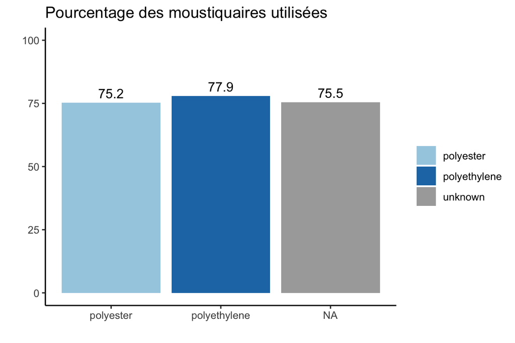

L’utilisation des moustiquaires par textile est-elle différente par region ?

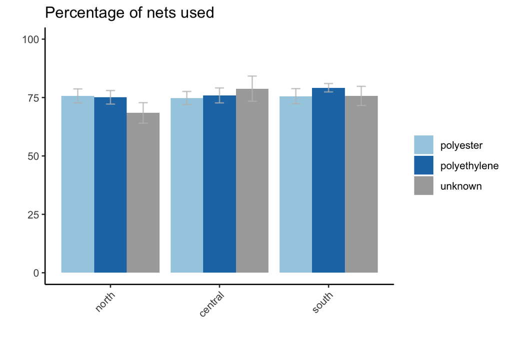

L’utilisation des moustiquaires par textile est-elle différente par milieu rural/urbain ?

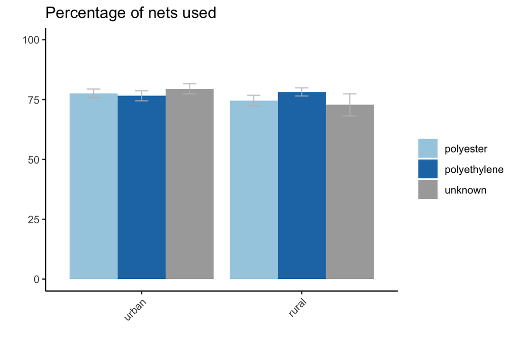

L’utilisation des moustiquaires par le textile est-elle différente selon le statut socio-économique ?

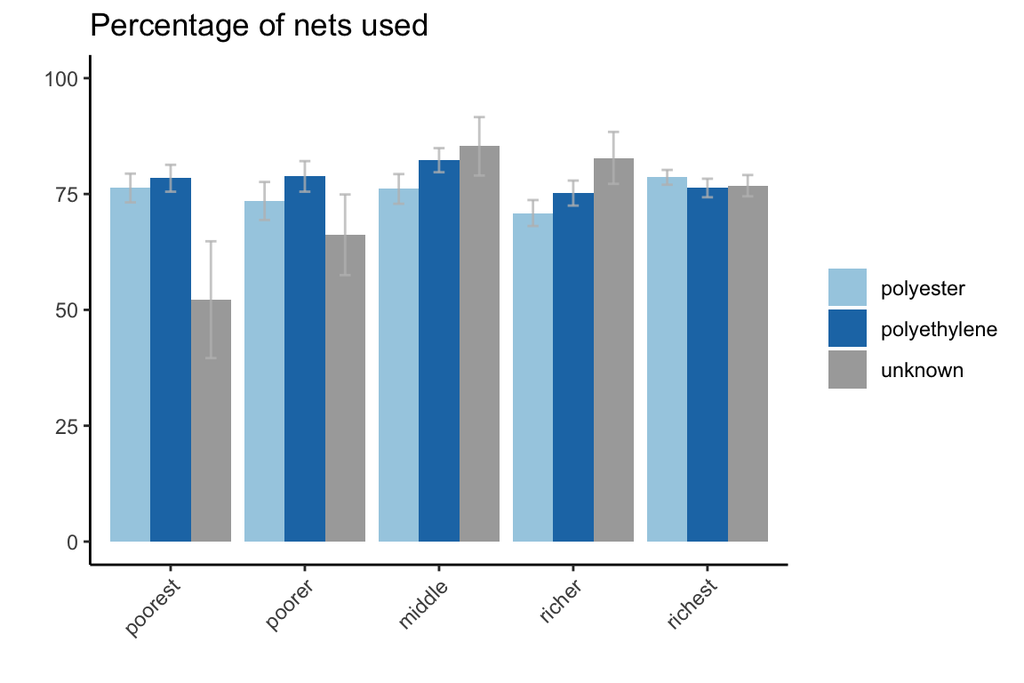

L’utilisation des moustiquaires par textile est-elle différente au cours du mois de l’année ?

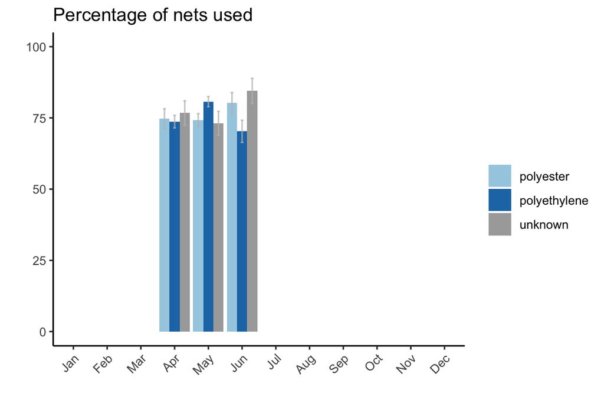

L’utilisation des moustiquaires par textile est-elle différente selon l’âge de la moustiquaire ?

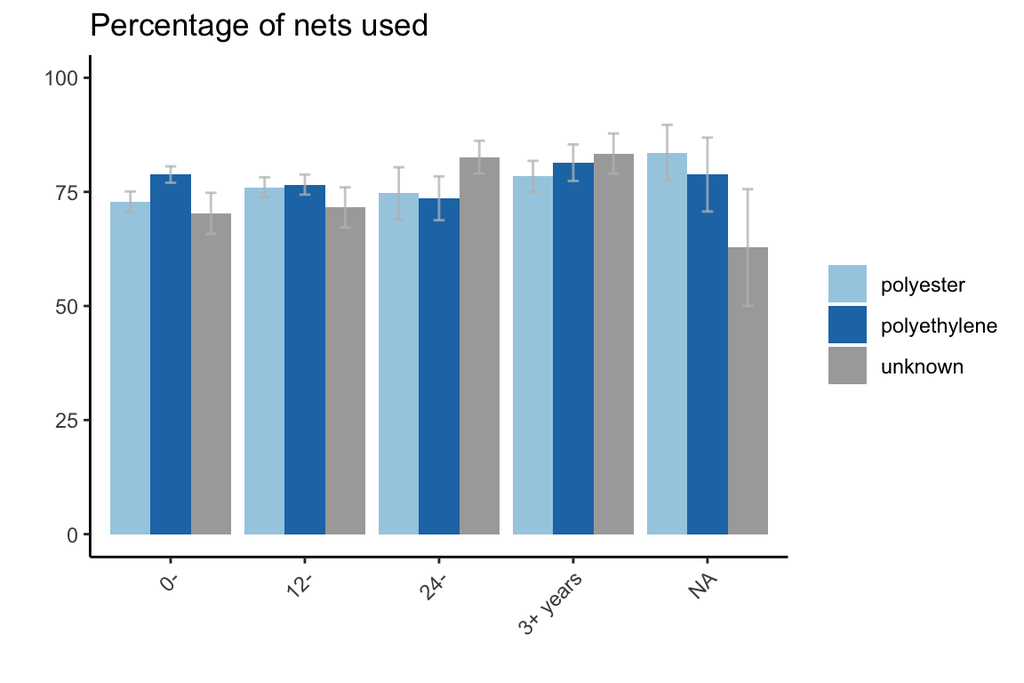

L’utilisation des moustiquaires par le textile est-elle différente de l’offre de moustiquaires des ménages ? Nous constatons généralement que les moustiquaires dans les ménages qui en ont « trop » sont globalement moins utilisées. Est-ce le cas ici ?

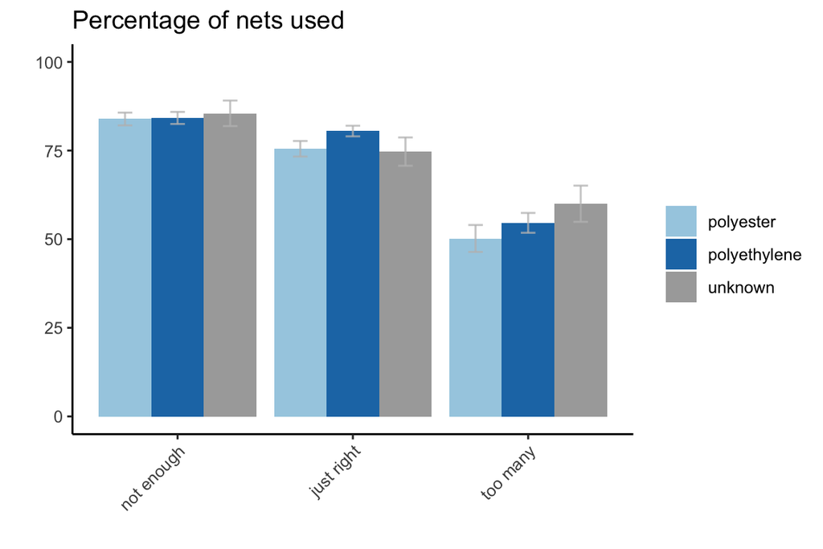

# Évaluer l’association entre l’utilisation de la moustiquaire et son textile, en contrôlant les covariables

Après avoir examiné les modèles d’utilisation des moustiquaires par le textile et les covariables, nous pouvons utiliser des modèles linéaires généralisés pour évaluer les associations entre les covariables et notre variable de résultat pour savoir si une moustiquaire particulière a été utilisée la nuit précédente.

Nous pouvons construire le modèle multivarié. Lors du contrôle des facteurs contextuels, le textile est-il associé à des différences significatives dans l’utilisation d’une moustiquaire ?

| **Characteristic** | **OR**<sup>1</sup> | **95% CI**<sup>1</sup> | **p-value** |
| --- | --- | --- | --- |
| textile |  |  |  |
| polyester | — | — |  |
| polyethylene | 1.11 | 0.91, 1.37 | 0.3 |
| household net supply |  |  |  |
| not enough | — | — |  |
| just right | 0.67 | 0.55, 0.80 | <0.001 |
| too many | 0.19 | 0.15, 0.25 | <0.001 |
| month of interview | 1.22 | 1.00, 1.50 | 0.047 |
| region |  |  |  |
| north | — | — |  |
| central | 0.84 | 0.58, 1.23 | 0.4 |
| south | 1.17 | 0.83, 1.66 | 0.4 |
| type of place of residence |  |  |  |
| urban | — | — |  |
| rural | 0.92 | 0.67, 1.25 | 0.6 |
| wealth index combined |  |  |  |
| poorest | — | — |  |
| poorer | 1.04 | 0.76, 1.41 | 0.8 |
| middle | 1.23 | 0.92, 1.64 | 0.2 |
| richer | 1.02 | 0.77, 1.35 | 0.9 |
| richest | 1.34 | 0.94, 1.92 | 0.11 |
| netagegr |  |  |  |
| 0- | — | — |  |
| 12- | 1.03 | 0.83, 1.27 | 0.8 |
| 24- | 0.81 | 0.52, 1.25 | 0.3 |
| 3+ years | 1.16 | 0.78, 1.74 | 0.5 |

<sup>*1*</sup> OR = Odds Ratio, CI = Confidence Interval

Que remarquez-vous sur les résultats du modèle multivarié ? Quelles covariables sont significativement associées et lesquelles ont les plus fortes réductions ou augmentations du rapport de cotes ? Le textile de la moustiquaire est-il significativement associé au fait que la moustiquaire a été utilisée la nuit précédente ?

Dans le modèle ci-dessus, nous voyons que les probabilités d’utilisation d’une moustiquaire imprégnée de polyéthylène la nuit précédente sont 1.114, par rapport aux probabilités d’utilisation d’une moustiquaire en polyester, avec une valeur p de 0.3.

# Le textile est-il associé à des différences d’utilisation des moustiquaires?

> Compte tenu des résultats ci-dessus, il n’y a aucune preuve suggérant que le textile de la moustiquaire fait une différence substantielle dans l’utilisation globale de la moustiquaire.

# Prise en compte des préférences des répondants à l’enquête pour les moustiquaires d’un textile particulier

Très peu d’enquêtes demandent aux personnes interrogées quel textile de moustiquaire elles préfèrent, et encore moins demandent aux personnes interrogées la force de cette préférence. Si, toutefois, des données sont disponibles sur les « préférences déclarées » (ce que les répondants déclarent comme leur préférence), cela peut être évalué parallèlement au comportement d’utilisation de la moustiquaire observé.

Dans des travaux antérieurs sur les préférences en MII, une variable binaire a été construite au niveau du ménage pour savoir si le ménage préférait, par ex. moustiquaires en polyester. Cette variable a ensuite été incluse dans les modèles présentés précédemment en tant que covariable. Dans de nombreux cas, le fait qu’un ménage préférait les moustiquaires d’un certain type n’était pas fortement associé au résultat de l’utilisation des moustiquaires. Cela pourrait être dû au fait que la préférence n’était pas le seul facteur déterminant, ou parce que le ménage ne disposait que de moustiquaires d’un type différent et a choisi de les utiliser (peut-être à contrecœur) plutôt que de rester sans protection contre le paludisme.

Les préférences déclarées en elles-mêmes ne devraient pas être utilisées pour justifier l’achat de moustiquaires d’un seul textile ; l’analyse de l’utilisation des moustiquaires observée à partir des ensembles de données d’enquête fournira les informations nécessaires sur la façon dont les moustiquaires sont utilisées. Cependant, lorsque les deux types d’informations sont disponibles, ils peuvent être utilisés en combinaison pour évaluer la force de ces préférences par rapport à d’autres facteurs déterminants.

# Étapes si les données ne sont pas disponibles

Si les données d’enquête sont anciennes, incomplètes ou si les distributions de masse récentes n’ont impliqué que des moustiquaires d’un seul textile, les pays peuvent avoir besoin de collecter des données supplémentaires et/ou de s’assurer qu’un mélange de MII est distribué dans les prochaines campagnes.

# Sources de données supplémentaires pouvant être utiles pour la triangulation

## Taux d’échange des ITN de campagne aux points de distribution - les taux d’échange diffèrent-ils pour les ITN de différents textiles?

Lorsque les taux d’échange (proportion de MII récupéré sur le nombre disponible ou attendu) pour les campagnes de masse sont disponibles et peuvent être directement liées au type de MII distribuées, de préférence au niveau du district, cela peut être utile à examiner. La question est de savoir si les taux d’échange des MII diffèrent du fait que le textile de la moustiquaire est distribué aux points de distribution. (Pour les campagnes de distribution porte-à-porte, nous n’attendons pas de taux élevés de refus de MII une fois les équipes de distribution sont à la porte.)

Les taux d’échange pour les différentes communautés pour les campagnes de MII sont susceptibles de différer pour des raisons non liées au textile, et il est donc important de prendre en compte ces autres facteurs potentiels lors de l’interprétation des données de taux d’échange. Des observations anecdotiques au cours de certaines campagnes peuvent attribuer des taux d’echange réduits au fait de ne pas vouloir s’embêter avec l’effort de récupérer les MII si elles sont le textile le moins préféré, et ces observations sont importantes. Il est crucial de considérer les autres options que les ménages peuvent avoir pour la prévention des piqures des moustiques lorsqu’ils refusent de ramasser les MII ; peut-être peuvent-ils accéder à leur MII préférée sur le marché ou en pharmacie, ou ont-ils d’autres options telles que des spirales/serpentins ou des sprays qui, selon eux, les protègent suffisamment, ou (et) ils estiment que leur risque de conséquences graves du paludisme est faible. Dans certains de ces contextes, il est possible que la fourniture de la moustiquaire préférée entraîne une augmentation de l’utilisation des MII, mais n’entraîne pas soudainement que tout le monde utilise des MII tout le temps, étant donné d’autres facteurs contribuant à la faible utilisation globale de la moustiquaire.

## Données de surveillance de la durabilité - les comportements de rétention et d’entretien diffèrent-ils pour les MII de différents textiles?

Il est possible que les moustiquaires qui sont moins préférées soient soumises à des comportements d’entretien et de réparation des moustiquaires moins prudents, ou soient distribuées à des taux plus élevés, ou jetées plus tôt. Compte tenu de la taille de l’échantillon et de la conception des activités de surveillance de la durabilité, il serait très difficile de retracer les différences de rétention des filets et d’intégrité physique spécifiquement au textile du filet. Nous serions également prudents en nous appuyant sur des méta-analyses de données de durabilité multi-pays pour étudier l’impact du textile sur la rétention et l’intégrité physique, étant donné le taux élevé de variation de la durabilité des moustiquaires de la même marque dans différents contextes géographiques et sociaux. Cependant, il peut être utile d’exploiter ces données lors de la triangulation à partir des données d’enquête auprès des ménages et des données sur les taux de rachat, et d’évaluer si les résultats sont alignés ou mal alignés.